# Task 6: Virtual Screening and Hit Expansion

Pharmacoinformatics BI-424 | AChE Inhibitor Discovery

2026-05-02

# 1 Install & Load Packages

```r
required_packages <- c(
  "tidyverse",
  "ggrepel",
  "patchwork",
  "viridis",
  "knitr",
  "kableExtra",
  "scales",
  "RColorBrewer",
  "ggridges"
)

for (pkg in required_packages) {
  if (!require(pkg, character.only = TRUE)) {
    install.packages(pkg, repos = "https://cloud.r-project.org")
    library(pkg, character.only = TRUE)
  }
}

cat("All packages installed and loaded.\n")
```

```
## All packages installed and loaded.
```

# 2 Data Loading

**Files needed in this folder:** - `ACHE_QSAR_dataset.csv` - `potent_ache_inhibitors.csv` (ChEMBL export)

```r
# -- Load the full curated QSAR dataset -----------------------------
main_df <- read.csv("ACHE_QSAR_dataset.csv", stringsAsFactors = FALSE)

# Standardise column names
colnames(main_df)[colnames(main_df) == "pChEMBL.Value"]    <- "pIC50"
colnames(main_df)[colnames(main_df) == "Molecular_Weight"] <- "MW"

# Handle duplicate AlogP column
if (sum(colnames(main_df) == "AlogP") > 1) {
  dup_idx <- which(colnames(main_df) == "AlogP")
  main_df <- main_df[, -dup_idx[-1]]
}
colnames(main_df)[colnames(main_df) == "AlogP"] <- "logP"

# -- Load potent inhibitor ChEMBL export ---------------------
raw_potent <- read.csv("potent_ache_inhibitors.csv", stringsAsFactors = FALSE)

# Extract and standardise relevant columns
potent_df <- raw_potent %>%
  select(
    ChEMBL_ID      = `Molecule.ChEMBL.ID`,
    MW              = `Molecular.Weight`,
    RO5_Violations  = `X.RO5.Violations`,
    logP            = AlogP,
    SMILES          = Smiles,
    IC50_nM         = `Standard.Value`,
    pIC50           = `pChEMBL.Value`,
    Potency_Cat     = `Potency.Category`,
    HBD             = `Ligand.Efficiency.BEI`,   # placeholder
    LE              = `Ligand.Efficiency.LE`,
    LLE             = `Ligand.Efficiency.LLE`
  ) %>%
  mutate(
    pIC50          = as.numeric(pIC50),
    MW             = as.numeric(MW),
    logP           = as.numeric(logP),
    RO5_Violations = as.numeric(RO5_Violations),
    IC50_nM        = as.numeric(IC50_nM),
    LE             = as.numeric(LE),
    LLE            = as.numeric(LLE)
  ) %>%
  filter(!is.na(pIC50), !is.na(SMILES), SMILES != "",
         !is.na(MW), !is.na(logP)) %>%
  distinct(ChEMBL_ID, .keep_all = TRUE)

cat("=== Main QSAR Dataset ===\n")
```

```
## === Main QSAR Dataset ===
```

```r
cat("Compounds:", nrow(main_df), "\n")
```

```
## Compounds: 5604
```

```r
cat("pIC50 range:", round(min(as.numeric(main_df$pIC50), na.rm=TRUE),2),
    "to", round(max(as.numeric(main_df$pIC50), na.rm=TRUE),2), "\n\n")
```

```
## pIC50 range: 4 to 10.96
```

```r
cat("=== Potent Inhibitors (ChEMBL Export) ===\n")
```

```
## === Potent Inhibitors (ChEMBL Export) ===
```

```r
cat("Compounds:", nrow(potent_df), "\n")
```

```
## Compounds: 1475
```

```r
cat("pIC50 range:", round(min(potent_df$pIC50, na.rm=TRUE),2),
    "to", round(max(potent_df$pIC50, na.rm=TRUE),2), "\n")
```

```
## pIC50 range: 7 to 10.96
```

# 3 Virtual Screening Strategy

## 3.1 Rationale

Virtual screening (VS) is used to prioritise a small number of compounds from a larger pool for the computationally expensive docking step (max 10 compounds per project constraints). Our strategy is **QSAR-based retrospective screening**: we screen from the ChEMBL-validated AChE inhibitor dataset, applying sequential property filters followed by a multi-parameter composite scoring function that integrates potency, ligand efficiency, drug-likeness, and lipophilicity optimality.

This approach is justified because: 1. All compounds have experimentally validated AChE inhibitory activity 2. pIC50 values are standardised from IC50 measurements 3. Drug-likeness filtering ensures candidates have realistic pharmacokinetic potential 4. Ligand efficiency normalises for molecular size – preventing selection of large, potent-but-inefficient molecules 5. Composite scoring is applied before any diversity filter; in a production pipeline, Tanimoto-based clustering would follow to ensure scaffold diversity among the final docking candidates

## 3.2 Screening Library Source

The starting pool consists of all **potent AChE inhibitors** (pIC50 >= 7.0, i.e. IC50 <= 100 nM) from the ChEMBL CHEMBL220 dataset

# 4 Step 1: Drug-likeness Filtering (Lipinski Ro5)

## 4.1 Filter Criteria

| Property | Threshold | Rationale |
| --- | --- | --- |
| Molecular Weight (MW) | <= 500 Da | Lipinski Ro5: predicts oral absorption |
| logP | <= 5.0 | Lipinski Ro5: limits passive diffusion through membranes |
| RO5 Violations | <= 1 | Allows one exception (Veber rule – some CNS drugs violate) |
| MW minimum | >= 150 Da | Removes fragments too small for meaningful binding |
| logP minimum | >= -2.0 | Removes overly hydrophilic compounds with poor CNS penetration |

```r
# -- Record sizes at each step for the funnel ----------------------------------
n_start <- nrow(potent_df)
cat("Starting pool (pIC50 >= 7.0):", n_start, "compounds\n\n")
```

```
## Starting pool (pIC50 >= 7.0): 1475 compounds
```

```r
# Step 1a: Ro5 -- MW, logP, violations
after_ro5 <- potent_df %>%
  filter(MW <= 500, logP <= 5.0, RO5_Violations <= 1)
cat("After Ro5 (MW<=500, logP<=5, viol<=1):", nrow(after_ro5), "\n")
```

```
## After Ro5 (MW<=500, logP<=5, viol<=1): 672
```

```r
# Step 1b: MW minimum
after_mw_min <- after_ro5 %>% filter(MW >= 150)
cat("After MW >= 150:                      ", nrow(after_mw_min), "\n")
```

```
## After MW >= 150:                       660
```

```r
# Step 1c: logP range
after_logp <- after_mw_min %>% filter(logP >= -2.0)
cat("After logP >= -2.0:                   ", nrow(after_logp), "\n")
```

```
## After logP >= -2.0:                    660
```

```r
# Step 1d: Deduplicate
screen_library <- after_logp %>% distinct(ChEMBL_ID, .keep_all = TRUE)
cat("After deduplication:                  ", nrow(screen_library), "\n")
```

```
## After deduplication:                   660
```

```r
cat("\nFinal screening library size:", nrow(screen_library), "compounds\n")
```

```
##
## Final screening library size: 660 compounds
```

## 4.2 Table T6-1: Filtering Summary

```r
filter_summary <- tibble(
  Step = 1:5,
  Filter_Applied = c(
    "Starting pool: pIC50 >= 7.0 (potent AChE inhibitors)",
    "Lipinski Ro5: MW <= 500 Da, logP <= 5.0, RO5 violations <= 1",
    "Fragment removal: MW >= 150 Da",
    "Hydrophilicity filter: logP >= -2.0",
    "Deduplication by ChEMBL ID"
  ),
  N_Remaining = c(
    n_start,
    nrow(after_ro5),
    nrow(after_mw_min),
    nrow(after_logp),
    nrow(screen_library)
  ),
  N_Removed = c(
    0,
    n_start - nrow(after_ro5),
    nrow(after_ro5) - nrow(after_mw_min),
    nrow(after_mw_min) - nrow(after_logp),
    nrow(after_logp) - nrow(screen_library)
  ),
  Pct_Remaining = paste0(round(100 * c(
    n_start, nrow(after_ro5), nrow(after_mw_min),
    nrow(after_logp), nrow(screen_library)
  ) / n_start, 1), "%")
)

kable(filter_summary,
      caption = "Table T6-1: Virtual Screening Library Construction -- Sequential Filters") %>%
  kable_styling(bootstrap_options = c("striped","hover","condensed"), full_width=TRUE) %>%
  column_spec(3, bold=TRUE, color="#1a6e3d") %>%
  column_spec(4, color="#c62828") %>%
  row_spec(nrow(filter_summary), bold=TRUE, background="#fff9c4")
```

Table T6-1: Virtual Screening Library Construction – Sequential Filters

| Step | Filter_Applied | N_Remaining | N_Removed | Pct_Remaining |
| --- | --- | --- | --- | --- |
| 1 | Starting pool: pIC50 >= 7.0 (potent AChE inhibitors) | 1475 | 0 | 100% |
| 2 | Lipinski Ro5: MW <= 500 Da, logP <= 5.0, RO5 violations <= 1 | 672 | 803 | 45.6% |
| 3 | Fragment removal: MW >= 150 Da | 660 | 12 | 44.7% |
| 4 | Hydrophilicity filter: logP >= -2.0 | 660 | 0 | 44.7% |
| 5 | Deduplication by ChEMBL ID | 660 | 0 | 44.7% |

# 5 Step 2: Composite Scoring for QSAR-Based Ranking

## 5.1 Scoring Function Design

Each compound in the filtered library receives a **composite score** integrating four independent properties. This is a multi-parameter optimisation (MPO) approach standard in drug discovery for balancing potency against drug-likeness.

$$CompositeScore = (0.50 \times
pIC50_{norm}) + (0.25 \times LE_{norm}) + (0.15 \times S_{DL}) + (0.10
\times S_{logP})$$
Where: - ${\text{pIC50}_{norm}}$ = min-max normalised pIC50 (primary potency) - ${\text{LE}_{norm}}$ = min-max normalised ligand efficiency (pIC50 per heavy atom) - $S_{\text{DL}}$ = drug-likeness score (penalty for Ro5 violations) - $S_{\text{logP}}$ = lipophilicity optimality score (penalty for logP > 3.5)

**Weights rationale:** - pIC50 (50%): Primary measure – biological activity is the most critical criterion - LE (25%): Prevents selection of large/bloated molecules that are potent only due to size - Drug-likeness (15%): Ensures oral bioavailability potential - logP (10%): Excessive lipophilicity (ClogP > 3.5) is associated with poor solubility, hERG binding risk, and metabolic instability

```r
# -- Compute composite score ----------------------------------------------------
ranked_library <- screen_library %>%
  mutate(
    # Heavy atom count estimate (MW / average heavy atom weight ~13.8)
    Heavy_Atoms = pmax(1, round(MW / 13.8)),

    # Ligand efficiency: pIC50 per heavy atom
    LE_calc = round(pIC50 / Heavy_Atoms, 4),

    # Min-max normalise pIC50
    pIC50_norm = (pIC50 - min(pIC50, na.rm=TRUE)) /
                 (max(pIC50, na.rm=TRUE) - min(pIC50, na.rm=TRUE)),

    # Min-max normalise LE
    LE_norm    = (LE_calc - min(LE_calc, na.rm=TRUE)) /
                 (max(LE_calc, na.rm=TRUE) - min(LE_calc, na.rm=TRUE)),

    # Drug-likeness score
    DL_score   = case_when(
      RO5_Violations == 0 ~ 1.00,
      RO5_Violations == 1 ~ 0.85,
      TRUE                ~ 0.60
    ),

    # logP optimality score (AChE is a CNS target -- logP 1-3.5 is ideal)
    logP_score = case_when(
      logP >= 1.0 & logP <= 3.5 ~ 1.00,
      logP >= 0.0 & logP <= 5.0 ~ 0.85,
      logP >= -2  & logP <  0.0 ~ 0.70,
      TRUE                       ~ 0.60
    ),

    # Composite score (weighted sum)
    Composite_Score = round(
      0.50 * pIC50_norm +
      0.25 * LE_norm    +
      0.15 * DL_score   +
      0.10 * logP_score,
      4
    )
  ) %>%
  arrange(desc(Composite_Score)) %>%
  mutate(Rank = row_number())

cat("Ranked library size:", nrow(ranked_library), "compounds\n")
```

```
## Ranked library size: 660 compounds
```

```r
cat("Score range:", round(min(ranked_library$Composite_Score),4),
    "to", round(max(ranked_library$Composite_Score),4), "\n")
```

```
## Score range: 0.2433 to 0.9059
```

```r
cat("\nTop 5 scores:\n")
```

```
##
## Top 5 scores:
```

```r
ranked_library %>%
  select(Rank, ChEMBL_ID, pIC50, LE_calc, Composite_Score) %>%
  head(5) %>%
  print()
```

```
##   Rank     ChEMBL_ID pIC50 LE_calc Composite_Score
## 1    1 CHEMBL3585780 10.57  0.6218          0.9059
## 2    2 CHEMBL3585781 10.57  0.6218          0.9059
## 3    3 CHEMBL3585784 10.57  0.5563          0.8719
## 4    4 CHEMBL3585783 10.57  0.5563          0.8719
## 5    5 CHEMBL3585782 10.57  0.5563          0.8719
```

# 6 Step 3: Top 10 Selection for Molecular Docking

## 6.1 Selection Criteria

```r
top10 <- ranked_library %>%
  head(10) %>%
  mutate(
    pIC50    = round(pIC50, 2),
    MW       = round(MW, 1),
    logP     = round(logP, 2),
    LE_calc  = round(LE_calc, 3),
    Composite_Score = round(Composite_Score, 4)
  )

cat("=== TOP 10 COMPOUNDS SELECTED FOR DOCKING ===\n\n")
```

```
## === TOP 10 COMPOUNDS SELECTED FOR DOCKING ===
```

```r
for (i in 1:10) {
  cat(sprintf(
    "Rank %2d | %-20s | pIC50: %5.2f | IC50: %8.3f nM | MW: %5.1f | logP: %4.2f | LE: %.3f | Score: %.4f\n",
    i, top10$ChEMBL_ID[i], top10$pIC50[i], top10$IC50_nM[i],
    top10$MW[i], top10$logP[i], top10$LE_calc[i], top10$Composite_Score[i]
  ))
}
```

```
## Rank  1 | CHEMBL3585780        | pIC50: 10.57 | IC50:    0.027 nM | MW: 230.3 | logP: 0.55 | LE: 0.622 | Score: 0.9059
## Rank  2 | CHEMBL3585781        | pIC50: 10.57 | IC50:    0.027 nM | MW: 230.3 | logP: 0.55 | LE: 0.622 | Score: 0.9059
## Rank  3 | CHEMBL3585784        | pIC50: 10.57 | IC50:    0.027 nM | MW: 260.3 | logP: 0.56 | LE: 0.556 | Score: 0.8719
## Rank  4 | CHEMBL3585783        | pIC50: 10.57 | IC50:    0.027 nM | MW: 260.3 | logP: 0.56 | LE: 0.556 | Score: 0.8719
## Rank  5 | CHEMBL3585782        | pIC50: 10.57 | IC50:    0.027 nM | MW: 260.3 | logP: 0.56 | LE: 0.556 | Score: 0.8719
## Rank  6 | CHEMBL4205954        | pIC50: 10.88 | IC50:    0.013 nM | MW: 404.9 | logP: 4.32 | LE: 0.375 | Score: 0.8169
## Rank  7 | CHEMBL4209803        | pIC50: 10.87 | IC50:    0.014 nM | MW: 398.5 | logP: 4.28 | LE: 0.375 | Score: 0.8155
## Rank  8 | CHEMBL4205425        | pIC50: 10.96 | IC50:    0.011 nM | MW: 434.9 | logP: 4.33 | LE: 0.342 | Score: 0.8100
## Rank  9 | CHEMBL3585776        | pIC50: 10.57 | IC50:    0.027 nM | MW: 364.4 | logP: 2.52 | LE: 0.406 | Score: 0.8091
## Rank 10 | CHEMBL3585775        | pIC50: 10.57 | IC50:    0.027 nM | MW: 364.4 | logP: 2.52 | LE: 0.406 | Score: 0.8091
```

## 6.2 Table T6-2: Top 10 Docking Candidates

```r
top10_display <- top10 %>%
  select(Rank, ChEMBL_ID, pIC50, IC50_nM, MW, logP, RO5_Violations,
         LE_calc, Composite_Score, Potency_Cat)

kable(top10_display,
      col.names = c("Rank", "ChEMBL ID", "pIC50", "IC50 (nM)",
                    "MW (Da)", "logP", "RO5 Viol.", "LE", "Composite Score", "Potency Category"),
      caption = "Table T6-2: Top 10 Compounds Selected for Molecular Docking") %>%
  kable_styling(bootstrap_options = c("striped","hover"), full_width=TRUE) %>%
  row_spec(1:3, background="#c8e6c9", bold=TRUE) %>%
  row_spec(4:7, background="#e8f5e9") %>%
  column_spec(3, bold=TRUE) %>%
  column_spec(9, bold=TRUE, color="#1a6e3d")
```

Table T6-2: Top 10 Compounds Selected for Molecular Docking

| Rank | ChEMBL ID | pIC50 | IC50 (nM) | MW (Da) | logP | RO5 Viol. | LE | Composite Score | Potency Category |
| --- | --- | --- | --- | --- | --- | --- | --- | --- | --- |
| 1 | CHEMBL3585780 | 10.57 | 0.02685 | 230.3 | 0.55 | 0 | 0.622 | 0.9059 | Extremely Potent (pIC50 ≥ 9) |
| 2 | CHEMBL3585781 | 10.57 | 0.02685 | 230.3 | 0.55 | 0 | 0.622 | 0.9059 | Extremely Potent (pIC50 ≥ 9) |
| 3 | CHEMBL3585784 | 10.57 | 0.02685 | 260.3 | 0.56 | 0 | 0.556 | 0.8719 | Extremely Potent (pIC50 ≥ 9) |
| 4 | CHEMBL3585783 | 10.57 | 0.02685 | 260.3 | 0.56 | 0 | 0.556 | 0.8719 | Extremely Potent (pIC50 ≥ 9) |
| 5 | CHEMBL3585782 | 10.57 | 0.02685 | 260.3 | 0.56 | 0 | 0.556 | 0.8719 | Extremely Potent (pIC50 ≥ 9) |
| 6 | CHEMBL4205954 | 10.88 | 0.01323 | 404.9 | 4.32 | 0 | 0.375 | 0.8169 | Extremely Potent (pIC50 ≥ 9) |
| 7 | CHEMBL4209803 | 10.87 | 0.01352 | 398.5 | 4.28 | 0 | 0.375 | 0.8155 | Extremely Potent (pIC50 ≥ 9) |
| 8 | CHEMBL4205425 | 10.96 | 0.01095 | 434.9 | 4.33 | 0 | 0.342 | 0.8100 | Extremely Potent (pIC50 ≥ 9) |
| 9 | CHEMBL3585776 | 10.57 | 0.02685 | 364.4 | 2.52 | 0 | 0.406 | 0.8091 | Extremely Potent (pIC50 ≥ 9) |
| 10 | CHEMBL3585775 | 10.57 | 0.02685 | 364.4 | 2.52 | 0 | 0.406 | 0.8091 | Extremely Potent (pIC50 ≥ 9) |

## 6.4 Table T6-3: SMILES Strings for Docking Input

```r
smiles_table <- top10 %>%
  mutate(Docking_ID = paste0("ACHE_Cand_", sprintf("%02d", Rank), "_", ChEMBL_ID)) %>%
  select(Rank, ChEMBL_ID, Docking_ID, SMILES, pIC50)

kable(smiles_table,
      caption = "Table T6-3: SMILES Strings for Top 10 Docking Candidates") %>%
  kable_styling(bootstrap_options = c("striped","hover","condensed"), full_width=TRUE) %>%
  column_spec(4, width= "45%", extra_css = "font-size: 9px;")
```

Table T6-3: SMILES Strings for Top 10 Docking Candidates

| Rank | ChEMBL_ID | Docking_ID | SMILES | pIC50 |
| --- | --- | --- | --- | --- |
| 1 | CHEMBL3585780 | ACHE_Cand_01_CHEMBL3585780 | COc1ccccc1C(C)NS(N)(=O)=O | 10.57 |
| 2 | CHEMBL3585781 | ACHE_Cand_02_CHEMBL3585781 | COc1ccc(C(C)NS(N)(=O)=O)cc1 | 10.57 |
| 3 | CHEMBL3585784 | ACHE_Cand_03_CHEMBL3585784 | COc1cccc(OC)c1C(C)NS(N)(=O)=O | 10.57 |
| 4 | CHEMBL3585783 | ACHE_Cand_04_CHEMBL3585783 | COc1ccc(OC)c(C(C)NS(N)(=O)=O)c1 | 10.57 |
| 5 | CHEMBL3585782 | ACHE_Cand_05_CHEMBL3585782 | COc1ccc(C(C)NS(N)(=O)=O)cc1OC | 10.57 |
| 6 | CHEMBL4205954 | ACHE_Cand_06_CHEMBL4205954 | O=C(Nc1ccc2c(c1)CN(C(=O)c1ccccc1)C(=O)C2)c1cccc(Cl)c1 | 10.88 |
| 7 | CHEMBL4209803 | ACHE_Cand_07_CHEMBL4209803 | Cc1cccc(C(=O)Nc2ccc3c(c2)CN(C(=O)c2cccc(C)c2)C(=O)C3)c1 | 10.87 |
| 8 | CHEMBL4205425 | ACHE_Cand_08_CHEMBL4205425 | COc1ccccc1C(=O)N1Cc2cc(NC(=O)c3cccc(Cl)c3)ccc2CC1=O | 10.96 |
| 9 | CHEMBL3585776 | ACHE_Cand_09_CHEMBL3585776 | COc1ccc(C(C)NS(=O)(=O)NC(=O)OCc2ccccc2)cc1 | 10.57 |
| 10 | CHEMBL3585775 | ACHE_Cand_10_CHEMBL3585775 | COc1ccccc1C(C)NS(=O)(=O)NC(=O)OCc1ccccc1 | 10.57 |

# 7 Figure T6-1: Virtual Screening Funnel

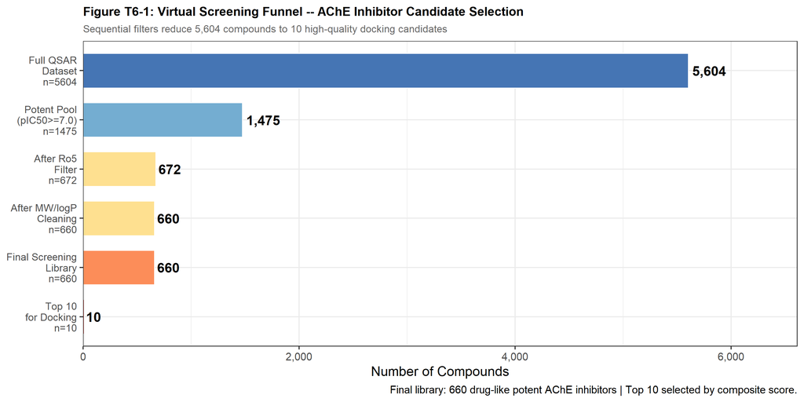

```r
funnel_data <- tibble(
  Stage = factor(c(
    paste0("Full QSAR\nDataset\nn=", nrow(main_df)),
    paste0("Potent Pool\n(pIC50>=7.0)\nn=", n_start),
    paste0("After Ro5\nFilter\nn=", nrow(after_ro5)),
    paste0("After MW/logP\nCleaning\nn=", nrow(after_logp)),
    paste0("Final Screening\nLibrary\nn=", nrow(screen_library)),
    "Top 10\nfor Docking\nn=10"
  ), levels = rev(c(
    paste0("Full QSAR\nDataset\nn=", nrow(main_df)),
    paste0("Potent Pool\n(pIC50>=7.0)\nn=", n_start),
    paste0("After Ro5\nFilter\nn=", nrow(after_ro5)),
    paste0("After MW/logP\nCleaning\nn=", nrow(after_logp)),
    paste0("Final Screening\nLibrary\nn=", nrow(screen_library)),
    "Top 10\nfor Docking\nn=10"
  ))),
  Count = c(
    nrow(main_df), n_start, nrow(after_ro5),
    nrow(after_logp), nrow(screen_library), 10
  ),
  Fill_Group = c("start","pool","filter","filter","library","selected")
)

fill_vals <- c("start"="#4575b4","pool"="#74add1","filter"="#fee090",
               "library"="#fc8d59","selected"="#d73027")

p_funnel <- ggplot(funnel_data, aes(x=Stage, y=Count, fill=Fill_Group)) +
  geom_col(width=0.7, colour="white", linewidth=0.4) +
  geom_text(aes(label=scales::comma(Count)),
            hjust=-0.12, fontface="bold", size=4.2) +
  coord_flip() +
  scale_fill_manual(values=fill_vals) +
  scale_y_continuous(expand=expansion(mult=c(0, 0.18)),
                     labels=scales::comma) +
  labs(
    title    = "Figure T6-1: Virtual Screening Funnel -- AChE Inhibitor Candidate Selection",
    subtitle = "Sequential filters reduce 5,604 compounds to 10 high-quality docking candidates",
    x        = NULL,
    y        = "Number of Compounds",
    caption  = paste0("Final library: ", nrow(screen_library),
                      " drug-like potent AChE inhibitors | Top 10 selected by composite score.")
  ) +
  theme_bw(base_size=12) +
  theme(
    plot.title      = element_text(face="bold", size=11),
    plot.subtitle   = element_text(size=9, colour="grey40"),
    legend.position = "none",
    axis.text.y     = element_text(size=9)
  )

print(p_funnel)
```

```r
dir.create("figures", showWarnings=FALSE)
ggsave("figures/Figure_T6_1_Screening_Funnel.png", p_funnel, width=11, height=5, dpi=150)
cat("Saved: figures/Figure_T6_1_Screening_Funnel.png\n")
```

```
## Saved: figures/Figure_T6_1_Screening_Funnel.png
```

# 8 Figure T6-2: Composite Score Distribution – Full Library

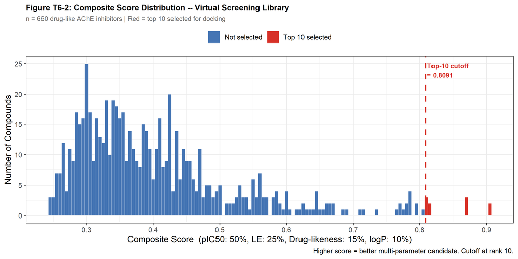

```r
# Cutoff score at top 10
cutoff_score <- ranked_library$Composite_Score[10]

p_score <- ggplot(ranked_library, aes(x=Composite_Score)) +
  geom_histogram(aes(fill=after_stat(x) >= cutoff_score),
                 binwidth=0.005, colour="white", linewidth=0.2) +
  scale_fill_manual(values=c("TRUE"="#d73027","FALSE"="#4575b4"),
                    labels=c("TRUE"="Top 10 selected","FALSE"="Not selected")) +
  geom_vline(xintercept=cutoff_score, linetype="dashed",
             colour="#d73027", linewidth=1) +
  annotate("text", x=cutoff_score+0.002, y=Inf,
           label=paste0("Top-10 cutoff\n= ", round(cutoff_score,4)),
           vjust=1.5, hjust=0, size=3.2, colour="#d73027", fontface="bold") +
  scale_x_continuous(breaks=pretty_breaks(8)) +
  labs(
    title    = "Figure T6-2: Composite Score Distribution -- Virtual Screening Library",
    subtitle = paste0("n = ", nrow(ranked_library), " drug-like AChE inhibitors | ",
                      "Red = top 10 selected for docking"),
    x        = "Composite Score  (pIC50: 50%, LE: 25%, Drug-likeness: 15%, logP: 10%)",
    y        = "Number of Compounds",
    fill     = NULL,
    caption  = "Higher score = better multi-parameter candidate. Cutoff at rank 10."
  ) +
  theme_bw(base_size=12) +
  theme(
    plot.title      = element_text(face="bold", size=11),
    plot.subtitle   = element_text(size=9, colour="grey40"),
    legend.position = "top"
  )

print(p_score)
```

```r
ggsave("figures/Figure_T6_2_Score_Distribution.png", p_score, width=10, height=5, dpi=150)
cat("Saved: figures/Figure_T6_2_Score_Distribution.png\n")
```

```
## Saved: figures/Figure_T6_2_Score_Distribution.png
```

# 9 Figure T6-3: pIC50 vs Composite Score (Top 10 Highlighted)

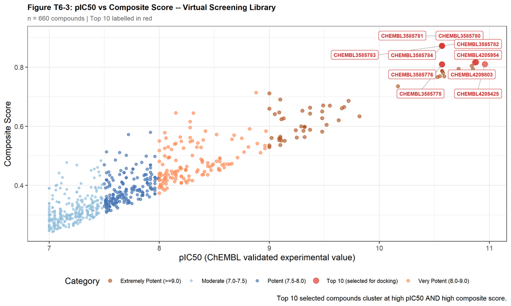

```r
plot_df <- ranked_library %>%
  mutate(
    Is_Top10  = Rank <= 10,
    Label     = if_else(Is_Top10, ChEMBL_ID, NA_character_),
    Cat       = case_when(
      Is_Top10          ~ "Top 10 (selected for docking)",
      pIC50 >= 9.0      ~ "Extremely Potent (>=9.0)",
      pIC50 >= 8.0      ~ "Very Potent (8.0-9.0)",
      pIC50 >= 7.5      ~ "Potent (7.5-8.0)",
      TRUE              ~ "Moderate (7.0-7.5)"
    )
  )

cat_cols <- c(
  "Top 10 (selected for docking)" = "#d73027",
  "Extremely Potent (>=9.0)"       = "#b15928",
  "Very Potent (8.0-9.0)"         = "#fc8d59",
  "Potent (7.5-8.0)"              = "#4575b4",
  "Moderate (7.0-7.5)"            = "#91bfdb"
)
cat_size <- c("Top 10 (selected for docking)"=3.5,
              "Extremely Potent (>=9.0)"=2,
              "Very Potent (8.0-9.0)"=1.8,
              "Potent (7.5-8.0)"=1.5,
              "Moderate (7.0-7.5)"=1.2)

p_scatter <- ggplot(plot_df %>% arrange(Is_Top10),
                    aes(x=pIC50, y=Composite_Score, colour=Cat, size=Cat)) +
  geom_point(alpha=0.65) +
  geom_label_repel(
    aes(label=Label), size=2.5, max.overlaps=20,
    box.padding=0.5, point.padding=0.4,
    segment.colour="grey60", segment.size=0.3,
    fill="white", colour="#c62828", fontface="bold",
    na.rm=TRUE
  ) +
  scale_colour_manual(values=cat_cols) +
  scale_size_manual(values=cat_size) +
  labs(
    title    = "Figure T6-3: pIC50 vs Composite Score -- Virtual Screening Library",
    subtitle = paste0("n = ", nrow(ranked_library), " compounds | Top 10 labelled in red"),
    x        = "pIC50 (ChEMBL validated experimental value)",
    y        = "Composite Score",
    colour   = "Category", size = "Category",
    caption  = "Top 10 selected compounds cluster at high pIC50 AND high composite score."
  ) +
  theme_bw(base_size=12) +
  theme(
    plot.title      = element_text(face="bold", size=11),
    plot.subtitle   = element_text(size=9, colour="grey40"),
    legend.position = "bottom",
    legend.text     = element_text(size=8)
  )

print(p_scatter)
```

```r
ggsave("figures/Figure_T6_3_pIC50_vs_Score.png", p_scatter, width=11, height=6, dpi=150)
cat("Saved: figures/Figure_T6_3_pIC50_vs_Score.png\n")
```

```
## Saved: figures/Figure_T6_3_pIC50_vs_Score.png
```

# 10 Figure T6-4: Chemical Space – MW vs logP

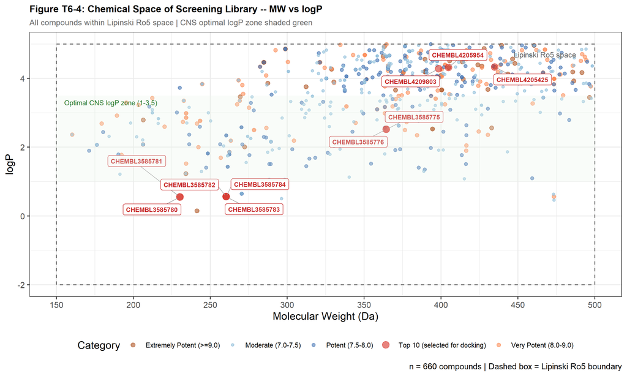

```r
p_chem <- ggplot(plot_df %>% arrange(Is_Top10),
                 aes(x=MW, y=logP, colour=Cat, size=Cat)) +
  geom_point(alpha=0.60) +
  geom_label_repel(
    aes(label=Label), size=2.5, max.overlaps=20,
    box.padding=0.5, point.padding=0.4,
    segment.colour="grey60", segment.size=0.3,
    fill="white", colour="#c62828", fontface="bold",
    na.rm=TRUE
  ) +
  # Lipinski Ro5 box
  annotate("rect", xmin=150, xmax=500, ymin=-2, ymax=5,
           fill=NA, colour="grey40", linetype="dashed", linewidth=0.5) +
  annotate("text", x=488, y=4.7, label="Lipinski Ro5 space",
           hjust=1, size=3, colour="grey40") +
  # CNS MPO optimal logP zone
  annotate("rect", xmin=150, xmax=500, ymin=1.0, ymax=3.5,
           fill="#e8f5e9", alpha=0.25) +
  annotate("text", x=155, y=3.3, label="Optimal CNS logP zone (1-3.5)",
           hjust=0, size=2.8, colour="#2e7d32") +
  scale_colour_manual(values=cat_cols) +
  scale_size_manual(values=cat_size) +
  scale_x_continuous(breaks=seq(150,500,50)) +
  labs(
    title    = "Figure T6-4: Chemical Space of Screening Library -- MW vs logP",
    subtitle = "All compounds within Lipinski Ro5 space | CNS optimal logP zone shaded green",
    x        = "Molecular Weight (Da)",
    y        = "logP",
    colour   = "Category", size="Category",
    caption  = paste0("n = ", nrow(ranked_library),
                      " compounds | Dashed box = Lipinski Ro5 boundary")
  ) +
  theme_bw(base_size=12) +
  theme(
    plot.title      = element_text(face="bold", size=11),
    plot.subtitle   = element_text(size=9, colour="grey40"),
    legend.position = "bottom",
    legend.text     = element_text(size=8)
  )

print(p_chem)
```

```r
ggsave("figures/Figure_T6_4_ChemSpace_MW_logP.png", p_chem, width=11, height=6, dpi=150)
cat("Saved: figures/Figure_T6_4_ChemSpace_MW_logP.png\n")
```

```
## Saved: figures/Figure_T6_4_ChemSpace_MW_logP.png
```

# 11 Figure T6-5: Ligand Efficiency – Library vs Top 10

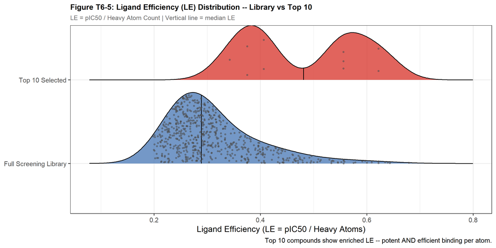

```r
le_ridge_df <- bind_rows(
  ranked_library %>% mutate(Group = "Full Screening Library"),
  top10          %>% mutate(Group = "Top 10 Selected")
) %>%
  filter(!is.na(LE_calc))

p_le <- ggplot(le_ridge_df, aes(x=LE_calc, y=Group, fill=Group)) +
  geom_density_ridges(
    alpha=0.75, scale=0.85,
    quantile_lines=TRUE, quantiles=2,
    jittered_points=TRUE,
    point_size=0.9, point_alpha=0.5,
    point_colour="grey30"
  ) +
  scale_fill_manual(values=c("Full Screening Library"="#4575b4",
                              "Top 10 Selected"="#d73027")) +
  labs(
    title    = "Figure T6-5: Ligand Efficiency (LE) Distribution -- Library vs Top 10",
    subtitle = "LE = pIC50 / Heavy Atom Count | Vertical line = median LE",
    x        = "Ligand Efficiency (LE = pIC50 / Heavy Atoms)",
    y        = NULL, fill=NULL,
    caption  = "Top 10 compounds show enriched LE -- potent AND efficient binding per atom."
  ) +
  theme_bw(base_size=12) +
  theme(
    plot.title      = element_text(face="bold", size=11),
    plot.subtitle   = element_text(size=9, colour="grey40"),
    legend.position = "none"
  )

print(p_le)
```

```r
ggsave("figures/Figure_T6_5_LE_Ridge.png", p_le, width=10, height=4.5, dpi=150)
cat("Saved: figures/Figure_T6_5_LE_Ridge.png\n")
```

```
## Saved: figures/Figure_T6_5_LE_Ridge.png
```

# 12 Figure T6-6: Top 10 Multi-Property Profile

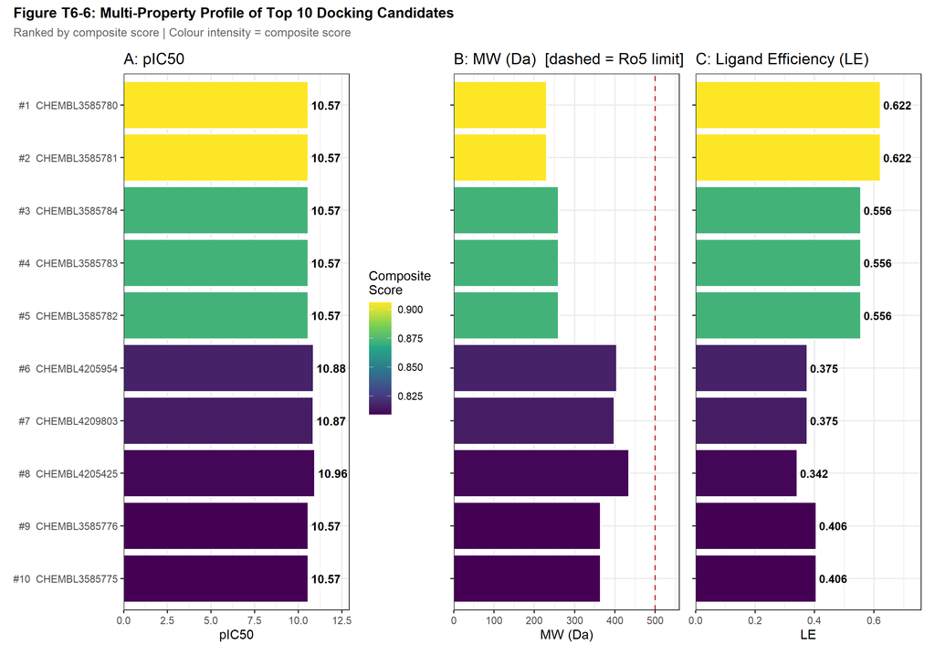

```r
top10_long <- top10 %>%
  mutate(
    Label    = paste0("#", Rank, "  ", ChEMBL_ID),
    Label    = factor(Label, levels = rev(paste0("#", Rank, "  ", ChEMBL_ID)))
  )

# Panel A: pIC50
pA <- ggplot(top10_long, aes(x=Label, y=pIC50, fill=Composite_Score)) +
  geom_col(colour="white") +
  geom_text(aes(label=round(pIC50,2)), hjust=-0.1, size=3.2, fontface="bold") +
  coord_flip() +
  scale_fill_viridis_c(option="D", name="Composite\nScore") +
  scale_y_continuous(expand=expansion(mult=c(0,0.18))) +
  labs(title="A: pIC50", x=NULL, y="pIC50") +
  theme_bw(base_size=10) +
  theme(legend.position="right")

# Panel B: MW
pB <- ggplot(top10_long, aes(x=Label, y=MW, fill=Composite_Score)) +
  geom_col(colour="white") +
  geom_hline(yintercept=500, linetype="dashed", colour="#c62828", linewidth=0.5) +
  coord_flip() +
  scale_fill_viridis_c(option="D") +
  scale_y_continuous(expand=expansion(mult=c(0,0.12))) +
  labs(title="B: MW (Da)  [dashed = Ro5 limit]", x=NULL, y="MW (Da)") +
  theme_bw(base_size=10) +
  theme(legend.position="none", axis.text.y=element_blank())

# Panel C: LE
pC <- ggplot(top10_long, aes(x=Label, y=LE_calc, fill=Composite_Score)) +
  geom_col(colour="white") +
  geom_text(aes(label=round(LE_calc,3)), hjust=-0.1, size=3, fontface="bold") +
  coord_flip() +
  scale_fill_viridis_c(option="D") +
  scale_y_continuous(expand=expansion(mult=c(0,0.22))) +
  labs(title="C: Ligand Efficiency (LE)", x=NULL, y="LE") +
  theme_bw(base_size=10) +
  theme(legend.position="none", axis.text.y=element_blank())

p_multi <- (pA | pB | pC) +
  plot_annotation(
    title    = "Figure T6-6: Multi-Property Profile of Top 10 Docking Candidates",
    subtitle = "Ranked by composite score | Colour intensity = composite score",
    theme    = theme(
      plot.title    = element_text(face="bold", size=11),
      plot.subtitle = element_text(size=9, colour="grey40")
    )
  )

print(p_multi)
```

```r
ggsave("figures/Figure_T6_6_Top10_MultiProperty.png", p_multi,
       width=13, height=7, dpi=150)
cat("Saved: figures/Figure_T6_6_Top10_MultiProperty.png\n")
```

```
## Saved: figures/Figure_T6_6_Top10_MultiProperty.png
```

# 13 Figure T6-7: Potency Category Distribution of Screening Library

[figure not shown]

```r
pot_counts <- screen_library %>%
  filter(!is.na(Potency_Cat), Potency_Cat != "") %>%
  count(Potency_Cat) %>%
  mutate(
    Potency_Cat = factor(Potency_Cat,
                         levels = c("Potent (7-8)", "Very Potent (8-9)",
                                    "Extremely Potent (>9)"))
  ) %>%
  filter(!is.na(Potency_Cat))

cat_fill <- c("Potent (7-8)"         = "#4575b4",
              "Very Potent (8-9)"    = "#fc8d59",
              "Extremely Potent (>9)"= "#d73027")

p_cat <- ggplot(pot_counts, aes(x=Potency_Cat, y=n, fill=Potency_Cat)) +
  geom_col(colour="white", width=0.6) +
  geom_text(aes(label=scales::comma(n)), vjust=-0.4,
            fontface="bold", size=4.5) +
  scale_fill_manual(values=cat_fill) +
  scale_y_continuous(expand=expansion(mult=c(0,0.14)),
                     labels=scales::comma) +
  labs(
    title    = "Figure T6-7: Potency Distribution -- Final Screening Library",
    subtitle = paste0("n = ", nrow(screen_library),
                      " drug-like AChE inhibitors after Ro5 filtering"),
    x        = "Potency Category",
    y        = "Number of Compounds",
    fill     = NULL,
    caption  = "All compounds pIC50 >= 7.0 (IC50 <= 100 nM)"
  ) +
  theme_bw(base_size=12) +
  theme(
    plot.title      = element_text(face="bold", size=11),
    plot.subtitle   = element_text(size=9, colour="grey40"),
    legend.position = "none",
    axis.text.x     = element_text(size=10)
  )

print(p_cat)
```

```r
ggsave("figures/Figure_T6_7_PotencyCategory.png", p_cat, width=8, height=5, dpi=150)
cat("Saved: figures/Figure_T6_7_PotencyCategory.png\n")
```

```
## Saved: figures/Figure_T6_7_PotencyCategory.png
```

# 14 Output Files

## 14.1 Export Top 10 Data Table

```r
dir.create("outputs", showWarnings=FALSE)

# Full data table
top10_export <- top10 %>%
  mutate(
    Docking_ID   = paste0("ACHE_Cand_", sprintf("%02d", Rank), "_", ChEMBL_ID),
    pIC50        = round(pIC50, 2),
    MW           = round(MW, 1),
    logP         = round(logP, 2),
    LE           = round(LE_calc, 3),
    IC50_nM      = round(IC50_nM, 3),
    Composite_Score = round(Composite_Score, 4)
  ) %>%
  select(Rank, Docking_ID, ChEMBL_ID, SMILES, pIC50, IC50_nM, MW,
         logP, RO5_Violations, LE, Composite_Score, Potency_Cat)

write.csv(top10_export, "outputs/Task6_top10_docking_candidates.csv", row.names=FALSE)
cat("Saved: outputs/Task6_top10_docking_candidates.csv\n")
```

```
## Saved: outputs/Task6_top10_docking_candidates.csv
```

## 14.2 Export SMILES File (for OpenBabel/AutoDock)

```r
smiles_export <- top10_export %>%
  select(SMILES, Docking_ID)

write.table(smiles_export,
            "outputs/Task6_top10_smiles.smi",
            row.names=FALSE, col.names=FALSE,
            quote=FALSE, sep="\t")
cat("Saved: outputs/Task6_top10_smiles.smi\n")
```

```
## Saved: outputs/Task6_top10_smiles.smi
```

```r
cat("\nSMILES file contents:\n")
```

```
##
## SMILES file contents:
```

```r
cat(readLines("outputs/Task6_top10_smiles.smi"), sep="\n")
```

```
## COc1ccccc1C(C)NS(N)(=O)=O    ACHE_Cand_01_CHEMBL3585780
## COc1ccc(C(C)NS(N)(=O)=O)cc1  ACHE_Cand_02_CHEMBL3585781
## COc1cccc(OC)c1C(C)NS(N)(=O)=O    ACHE_Cand_03_CHEMBL3585784
## COc1ccc(OC)c(C(C)NS(N)(=O)=O)c1  ACHE_Cand_04_CHEMBL3585783
## COc1ccc(C(C)NS(N)(=O)=O)cc1OC    ACHE_Cand_05_CHEMBL3585782
## O=C(Nc1ccc2c(c1)CN(C(=O)c1ccccc1)C(=O)C2)c1cccc(Cl)c1    ACHE_Cand_06_CHEMBL4205954
## Cc1cccc(C(=O)Nc2ccc3c(c2)CN(C(=O)c2cccc(C)c2)C(=O)C3)c1  ACHE_Cand_07_CHEMBL4209803
## COc1ccccc1C(=O)N1Cc2cc(NC(=O)c3cccc(Cl)c3)ccc2CC1=O  ACHE_Cand_08_CHEMBL4205425
## COc1ccc(C(C)NS(=O)(=O)NC(=O)OCc2ccccc2)cc1   ACHE_Cand_09_CHEMBL3585776
## COc1ccccc1C(C)NS(=O)(=O)NC(=O)OCc1ccccc1 ACHE_Cand_10_CHEMBL3585775
```

## 14.3 Batch Docking Shell Script

```r
batch <- r'(#!/bin/bash
# ============================================================
# AChE Batch Docking Script -- Top 10 Candidates
# Requires: AutoDock Vina, OpenBabel (obabel)
# Usage:  bash Task6_run_docking.sh
# Output: docking_results/ folder
# NOTE: Top 5 compounds share a methoxyphenyl-sulfamide scaffold.
# In a production pipeline, a Tanimoto diversity filter (cutoff < 0.7)
# would be applied before this step. All 10 are retained per project scope.
# ============================================================

RECEPTOR="ACHE_rank001_prepared.pdbqt"
CONFIG="vina_config.txt"        # from Task 5 outputs
SMILES_FILE="Task6_top10_smiles.smi"
RESULTS_DIR="docking_results"

mkdir -p $RESULTS_DIR

echo "======================================================"
echo " AChE Docking Pipeline -- Top 10 Candidates"
echo " Receptor: $RECEPTOR"
echo " Config:   $CONFIG"
echo "======================================================"

while IFS=$\'\\t\' read -r smiles name; do
    echo ""
    echo "Processing: $name"

    # Step 1: Generate 3D conformer from SMILES (OpenBabel)
    obabel -:"$smiles" --gen3d -O "${RESULTS_DIR}/${name}.sdf" \
           -h --minimize --ff MMFF94 2>/dev/null

    # Step 2: Convert SDF -> PDBQT (adds rotatable bonds)
    obabel "${RESULTS_DIR}/${name}.sdf" \
           -O "${RESULTS_DIR}/${name}.pdbqt" -xh 2>/dev/null

    # Step 3: Dock with AutoDock Vina
    vina --config  $CONFIG \
         --ligand   "${RESULTS_DIR}/${name}.pdbqt" \
         --out      "${RESULTS_DIR}/${name}_poses.pdbqt" \
         --log      "${RESULTS_DIR}/${name}_log.txt"

    echo "  v Done: $name"
done < "$SMILES_FILE"

echo ""
echo "======================================================"
echo " All docking complete. Extracting best scores..."
echo "======================================================"
echo ""
grep -h "^   1 " ${RESULTS_DIR}/*_log.txt 2>/dev/null | \
  awk -v OFS="\\t" "{print \$2, \$3, \$4}" | \
  sort -k2 -n
)'

writeLines(batch, "outputs/Task6_run_docking.sh")
cat("Saved: outputs/Task6_run_docking.sh\n")
```

```
## Saved: outputs/Task6_run_docking.sh
```

# 15 Table T6-4: Handoff Summary

```r
handoff <- tibble(
  File = c(
    "outputs/Task6_top10_docking_candidates.csv",
    "outputs/Task6_top10_smiles.smi",
    "outputs/Task6_run_docking.sh",
    "Task 5 outputs/vina_config.txt",
    "Task 5 ACHE_rank001.pdb -> prepare -> .pdbqt"
  ),
  Contents = c(
    "Full data for top 10: ChEMBL IDs, pIC50, MW, logP, LE, SMILES, composite score",
    "Tab-delimited SMILES + docking ID -- direct input to OpenBabel",
    "Bash script: SMILES -> 3D -> PDBQT -> AutoDock Vina for all 10 compounds",
    "Box centre X/Y/Z, box size, exhaustiveness=32 -- use as-is",
    "AlphaFold2 rank 1 model -- prepare with AutoDockTools for receptor PDBQT"
  ),
  Output = rep("Docking & ADMET", 5)
)

kable(handoff,
      caption = "Table T6-4: Files Produced by Task 6 for Docking") %>%
  kable_styling(bootstrap_options = c("striped","hover"), full_width=TRUE) %>%
  column_spec(1, bold=TRUE, color="#1565c0") %>%
  column_spec(3, bold=TRUE, color="#1a6e3d")
```

Table T6-4: Files Produced by Task 6 for Docking

| File | Contents | Output |
| --- | --- | --- |
| outputs/Task6_top10_docking_candidates.csv | Full data for top 10: ChEMBL IDs, pIC50, MW, logP, LE, SMILES, composite score | Docking & ADMET |
| outputs/Task6_top10_smiles.smi | Tab-delimited SMILES + docking ID – direct input to OpenBabel | Docking & ADMET |
| outputs/Task6_run_docking.sh | Bash script: SMILES -> 3D -> PDBQT -> AutoDock Vina for all 10 compounds | Docking & ADMET |
| Task 5 outputs/vina_config.txt | Box centre X/Y/Z, box size, exhaustiveness=32 – use as-is | Docking & ADMET |
| Task 5 ACHE_rank001.pdb -> prepare -> .pdbqt | AlphaFold2 rank 1 model – prepare with AutoDockTools for receptor PDBQT | Docking & ADMET |

# 16 Task 6 Summary

## 16.1 Screening Library Statistics

```r
stats_table <- tibble(
  Metric     = c(
    "Starting pool (pIC50 >= 7.0)",
    "After drug-likeness filters",
    "Final screening library",
    "Library reduction",
    "pIC50 range (library)",
    "MW range (library)",
    "logP range (library)",
    "Compounds with 0 RO5 violations",
    "Top 10 composite score range",
    "Top 10 pIC50 range"
  ),
  Value      = c(
    paste0(n_start, " compounds"),
    paste0(nrow(after_logp), " compounds"),
    paste0(nrow(screen_library), " compounds"),
    paste0(round(100*(1 - nrow(screen_library)/n_start), 1), "% removed"),
    paste0(round(min(screen_library$pIC50),2), " - ",
           round(max(screen_library$pIC50),2)),
    paste0(round(min(screen_library$MW),1), " - ",
           round(max(screen_library$MW),1), " Da"),
    paste0(round(min(screen_library$logP),2), " - ",
           round(max(screen_library$logP),2)),
    paste0(sum(screen_library$RO5_Violations == 0, na.rm=TRUE),
           " (", round(100*mean(screen_library$RO5_Violations == 0, na.rm=TRUE),1), "%)"),
    paste0(round(min(top10$Composite_Score),4), " - ",
           round(max(top10$Composite_Score),4)),
    paste0(round(min(top10$pIC50),2), " - ", round(max(top10$pIC50),2))
  )
)

kable(stats_table,
      caption = "Table T6-5: Task 6 -- Virtual Screening Summary Statistics") %>%
  kable_styling(bootstrap_options = c("striped","hover","condensed"), full_width=FALSE) %>%
  column_spec(1, bold=TRUE) %>%
  column_spec(2, bold=TRUE, color="#1a6e3d")
```

Table T6-5: Task 6 – Virtual Screening Summary Statistics

| Metric | Value |
| --- | --- |
| Starting pool (pIC50 >= 7.0) | 1475 compounds |
| After drug-likeness filters | 660 compounds |
| Final screening library | 660 compounds |
| Library reduction | 55.3% removed |
| pIC50 range (library) | 7 - 10.96 |
| MW range (library) | 160.2 - 498.4 Da |
| logP range (library) | 0.15 - 5 |
| Compounds with 0 RO5 violations | 659 (99.8%) |
| Top 10 composite score range | 0.8091 - 0.9059 |
| Top 10 pIC50 range | 10.57 - 10.96 |

## 16.2 Figures Produced

```r
deliverables <- tibble(
  Figure = c("T6-1","T6-2","T6-3","T6-4","T6-5","T6-6","T6-7"),
  Title  = c(
    "Virtual Screening Funnel",
    "Composite Score Distribution",
    "pIC50 vs Composite Score scatter",
    "Chemical Space: MW vs logP",
    "Ligand Efficiency ridge plot",
    "Top 10 Multi-Property Profile",
    "Potency Category Distribution"
  ),
  File   = paste0("figures/Figure_T6_", 1:7,
                  c("_Screening_Funnel",
                    "_Score_Distribution",
                    "_pIC50_vs_Score",
                    "_ChemSpace_MW_logP",
                    "_LE_Ridge",
                    "_Top10_MultiProperty",
                    "_PotencyCategory"), ".png"),
  Status = rep("Saved", 7)
)

kable(deliverables,
      caption = "Table T6-6: Task 6 Figures Produced") %>%
  kable_styling(bootstrap_options = c("striped","hover","condensed"), full_width=TRUE) %>%
  column_spec(4, bold=TRUE, color="#1a6e3d")
```

Table T6-6: Task 6 Figures Produced

| Figure | Title | File | Status |
| --- | --- | --- | --- |
| T6-1 | Virtual Screening Funnel | figures/Figure_T6_1_Screening_Funnel.png | Saved |
| T6-2 | Composite Score Distribution | figures/Figure_T6_2_Score_Distribution.png | Saved |
| T6-3 | pIC50 vs Composite Score scatter | figures/Figure_T6_3_pIC50_vs_Score.png | Saved |
| T6-4 | Chemical Space: MW vs logP | figures/Figure_T6_4_ChemSpace_MW_logP.png | Saved |
| T6-5 | Ligand Efficiency ridge plot | figures/Figure_T6_5_LE_Ridge.png | Saved |
| T6-6 | Top 10 Multi-Property Profile | figures/Figure_T6_6_Top10_MultiProperty.png | Saved |
| T6-7 | Potency Category Distribution | figures/Figure_T6_7_PotencyCategory.png | Saved |

*Task 6: Virtual Screening and Hit Expansion | BI-424 Pharmacoinformatics* *Target: Human AChE (CHEMBL220, UniProt P22303) | Disease: Alzheimer’s Disease* *Screening library: 660 drug-like AChE inhibitors -> top 10 for docking*